# Contorta_Cone_Seed_Weights

Thomas Carlin

2022-10-25

## Read in + Clean Data

```r
setwd("~/VLR/RA1.1/Data")
dat <- read.csv("Seed_Weights.csv")

con <- dat[,c(2:14)] #Remove unnecessary columns

con$Site <- as.factor(con$Site)
colnames(con) <- c("ID","Site","Tree","Cone","Cone.Length.mm", "No.Seeds", "Tot.Sd.Wght.g", "No.Wingless.Sd", "Tot.Wless.Sd.Wght.g", "No.Winged.Sd", "Tot.Winged.Sd.Wght.g", "No.Immature.Sd", "Comments")

con <- con[!is.na(con$No.Seeds),] #Remove rows without seeds
con <- con[con$No.Seeds>0,] #Remove rows without seeds
head(con)
```

```
##     ID   Site Tree Cone Cone.Length.mm No.Seeds Tot.Sd.Wght.g No.Wingless.Sd
## 2  P1B Pukaki    1    B             41      115        0.4734             46
## 4  P1D Pukaki    1    D             40       97        0.5428             13
## 5  P1E Pukaki    1    E             40       83        0.4697             NA
## 6  P2A Pukaki    2    A             37       64        0.3238             NA
## 11 P3A Pukaki    3    A             46       93        0.4065             NA
## 12 P3B Pukaki    3    B             40       68        0.3205             NA
##    Tot.Wless.Sd.Wght.g No.Winged.Sd Tot.Winged.Sd.Wght.g No.Immature.Sd
## 2               0.1810           69               0.2721
## 4               0.0678           84               0.4675
## 5                   NA           NA                   NA              4
## 6                   NA           NA                   NA
## 11                  NA           NA                   NA
## 12                  NA           NA                   NA              3
##    Comments
## 2
## 4
## 5
## 6
## 11
## 12
```

```r
nrow(con)
```

```
## [1] 443
```

## Basic Box Plots

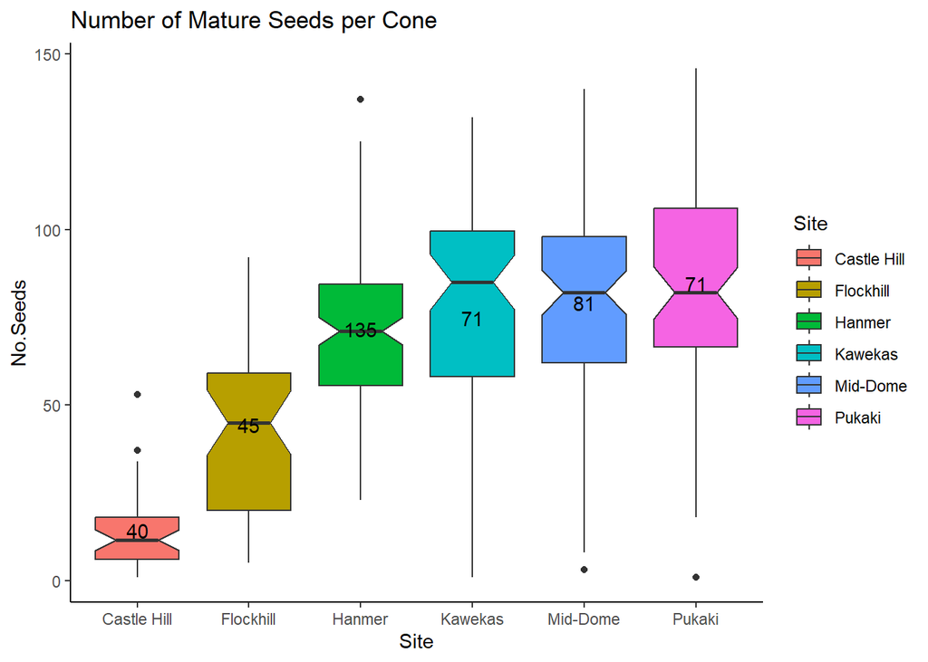

```r
give.n <- function(x){
   return(c(y = mean(x), label = length(x)))
}

ggplot(con, aes(x=Site, y=No.Seeds, fill=Site)) +
  geom_boxplot(notch=TRUE) +
  theme_classic() +
  labs(title="Number of Mature Seeds per Cone") +
  stat_summary(fun.data = give.n, geom = "text")
```

From the boxplot we can see that the number of seeds per cone varies between sites. However, this only accounts for the mature seed. Given that at some sites, e.g. Castle Hill, trees were in worse condition than at other sites we should see if the total number of seeds (including immature seeds) matches up between sites. If the trees were in better shape it’s possible these immature seeds would have matured.

We can also consider Castle Hill and Flockhill to be the same site.

```r
con$No.Immature.Sd <- as.numeric(str_replace_all(con$No.Immature.Sd, "[^[:alnum:]]", "")) #Remove non-numeric characters from column and convert to number
con$No.Immature.Sd[is.na(con$No.Immature.Sd)] <- 0
con$Tot.Seeds <- con$No.Seeds + con$No.Immature.Sd
```

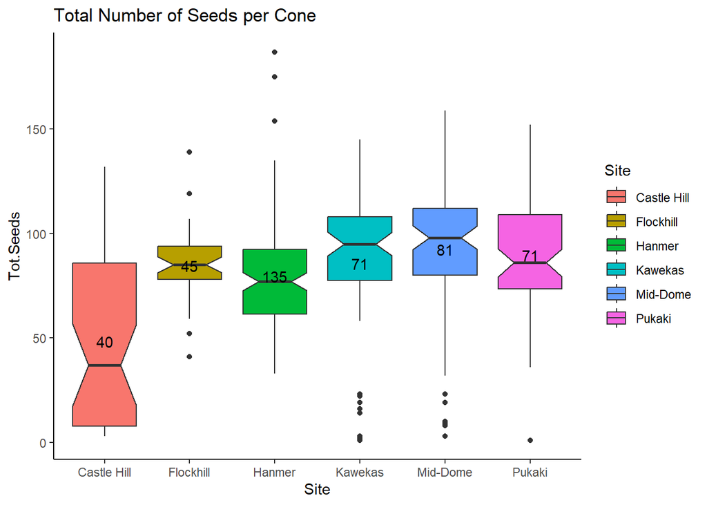

```r
ggplot(con, aes(x=Site, y=Tot.Seeds, fill=Site)) +
  geom_boxplot(notch=TRUE) +
  theme_classic() +
  labs(title="Total Number of Seeds per Cone") +
  stat_summary(fun.data = give.n, geom = "text")
```

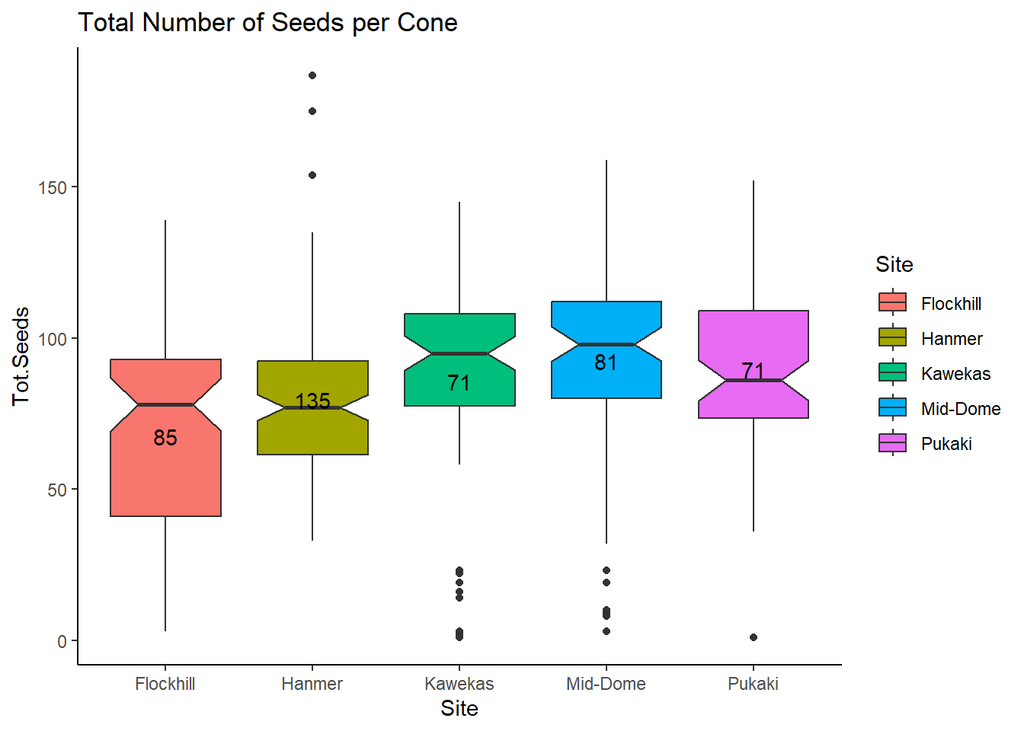

```r
con2 <- con
con2[con2$Site=="Castle Hill",2] <- "Flockhill"
ggplot(con2, aes(x=Site, y=Tot.Seeds, fill=Site)) +
  geom_boxplot(notch=TRUE) +
  theme_classic() +
  labs(title="Total Number of Seeds per Cone") +
  stat_summary(fun.data = give.n, geom = "text")
```

Total number of seeds produced by each cone is much more consistent across sites. We can check the same for cone length.

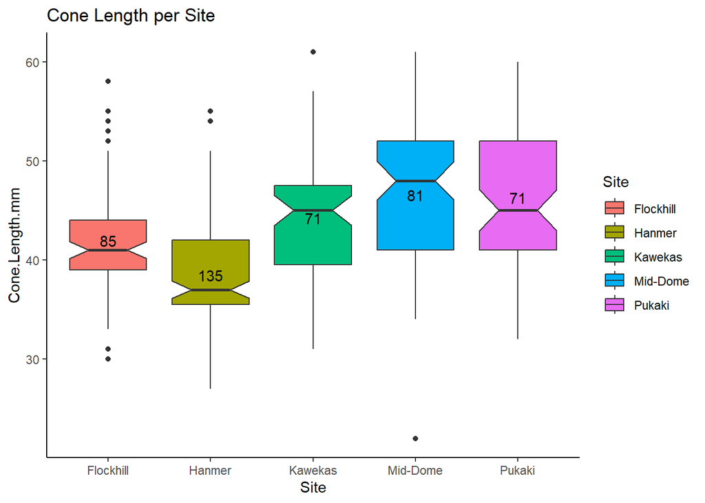

```r
ggplot(con2, aes(x=Site, y=Cone.Length.mm, fill=Site)) +
  geom_boxplot(notch=TRUE) +
  theme_classic() +
  labs(title="Cone Length per Site") +
  stat_summary(fun.data = give.n, geom = "text")
```

## Cone Length vs Number Seeds

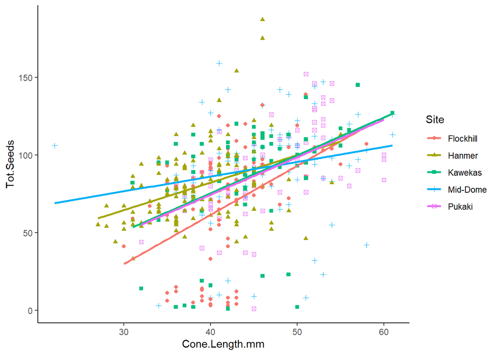

```r
ggplot(con2, aes(x=Cone.Length.mm, y=Tot.Seeds, shape=Site, color=Site)) +
  geom_point() +
  geom_smooth(method=lm, se=FALSE) +
  theme_classic()
```

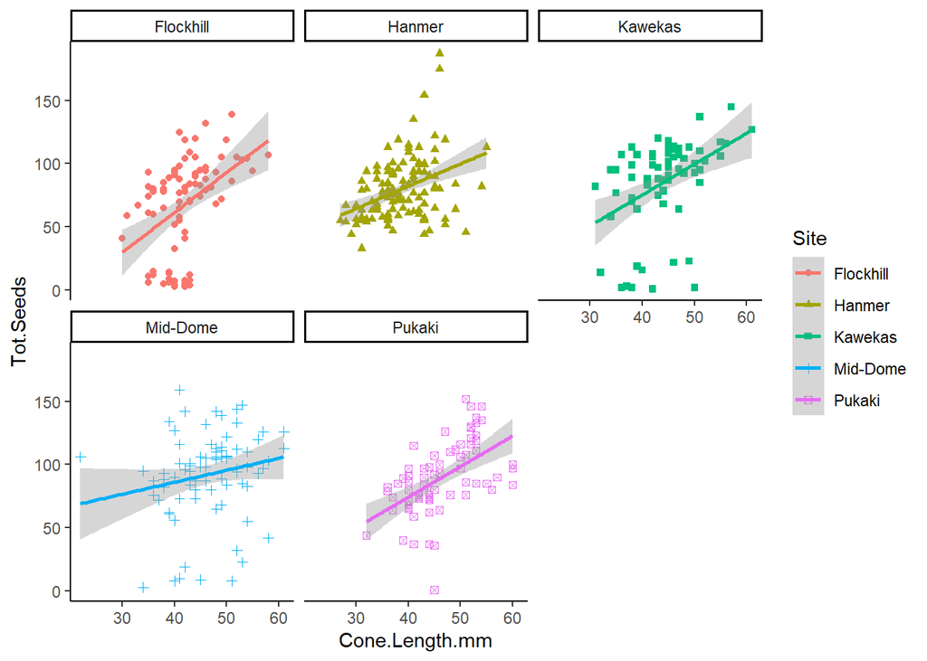

```r
ggplot(con2, aes(x=Cone.Length.mm, y=Tot.Seeds, shape=Site, color=Site)) +
  geom_point() +
  geom_smooth(method=lm) +
  theme_classic() +
  facet_wrap(~ Site, ncol=3)
```

## Cone Length vs MISM

```r
con2$MISM <- con2$Tot.Sd.Wght.g/con2$No.Seeds
```

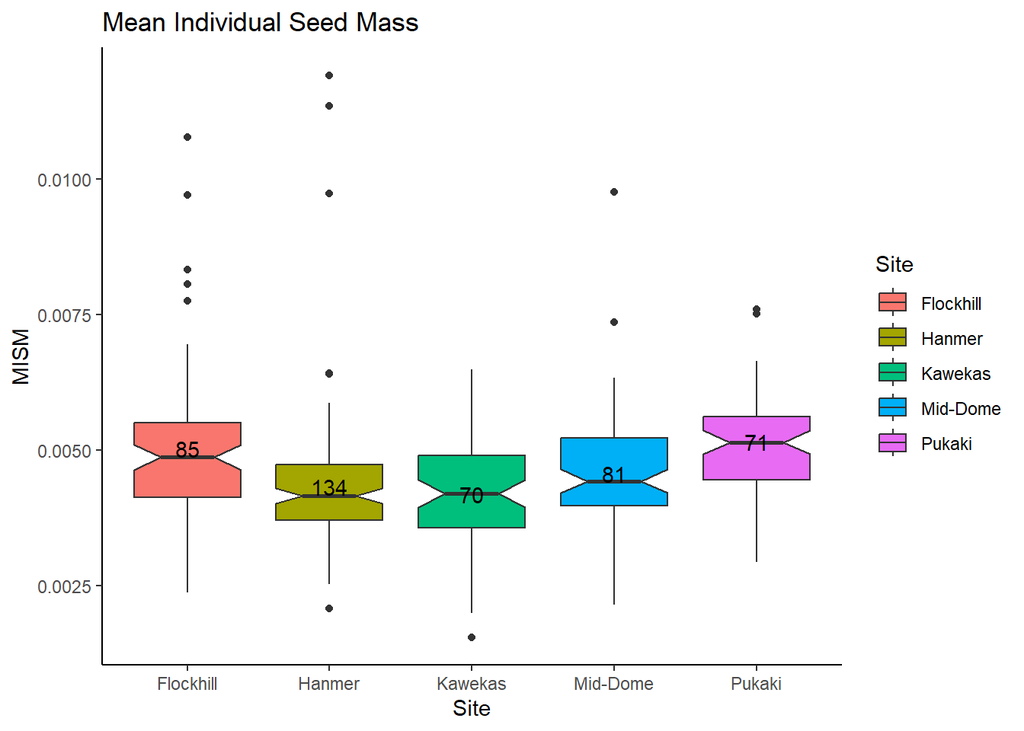

```r
ggplot(con2, aes(x=Site, y=MISM, fill=Site)) +
  geom_boxplot(notch=TRUE) +
  theme_classic() +
  labs(title="Mean Individual Seed Mass") +
  stat_summary(fun.data = give.n, geom = "text")
```

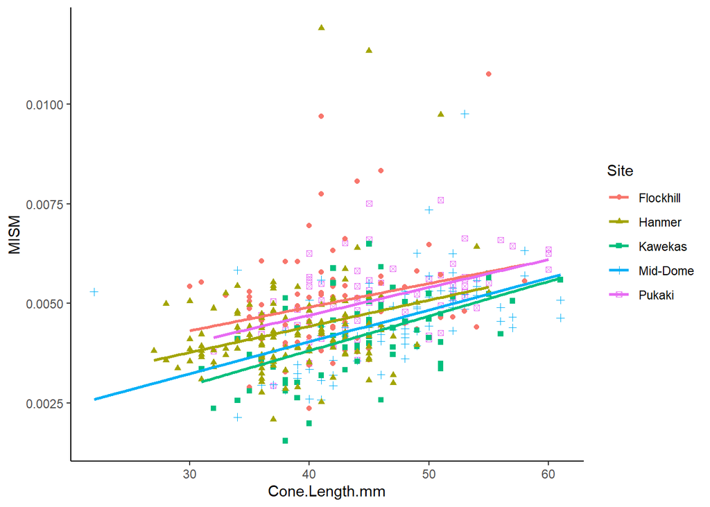

```r
ggplot(con2, aes(x=Cone.Length.mm, y=MISM, shape=Site, color=Site)) +
  geom_point() +
  geom_smooth(method=lm, se=FALSE) +
  theme_classic()
```

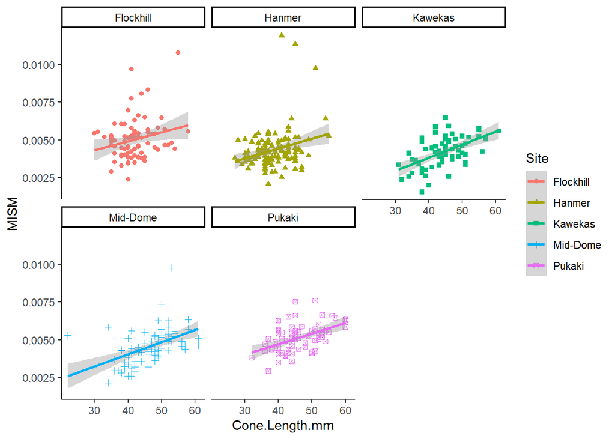

```r
ggplot(con2, aes(x=Cone.Length.mm, y=MISM, shape=Site, color=Site)) +
  geom_point() +
  geom_smooth(method=lm) +
  theme_classic() +
  facet_wrap(~ Site, ncol=3)
```

## Winged vs Wingless Seed

Do wings contribute a significant amount to the weight of a seed? (Only have a few rows of data here)

```r
con2$wingMISM <- con2$Tot.Winged.Sd.Wght.g/con2$No.Winged.Sd
con2$lessMISM <- con2$Tot.Wless.Sd.Wght.g/con2$No.Wingless.Sd
sum(!is.na(con2$wingMISM))
```

```
## [1] 11
```

```r
wing <- con2[!is.na(con2[,16]),c(1,2,16)]
less <- con2[!is.na(con2[,17]),c(1,2,17)]
wing$Group <- "Wing"
less$Group <- "Wingless"
colnames(wing)[3] <- "MISM"
colnames(less)[3] <- "MISM"
data <- rbind(wing,less)

group_by(data, Group) %>%
  summarise(
    count = n(),
    mean = mean(MISM, na.rm = TRUE),
    sd = sd(MISM, na.rm = TRUE)
  )
```

```
## # A tibble: 2 × 4
##   Group    count    mean      sd
##   <chr>    <int>   <dbl>   <dbl>
## 1 Wing        11 0.00464 0.00126
## 2 Wingless    11 0.00511 0.00370
```

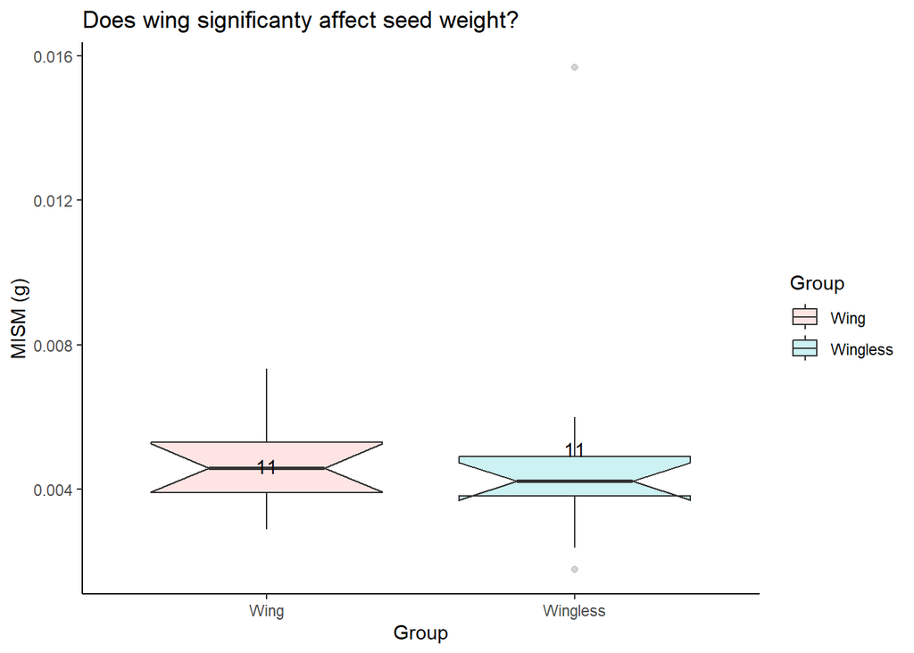

```r
ggplot(data, aes(x=Group, y=MISM)) +
  geom_boxplot(notch=TRUE, aes(fill=Group), alpha=0.2) +
  theme_classic() +
  labs(title="Does wing significanty affect seed weight?") +
  ylab("MISM (g)") +
  stat_summary(fun.data = give.n, geom = "text")
```

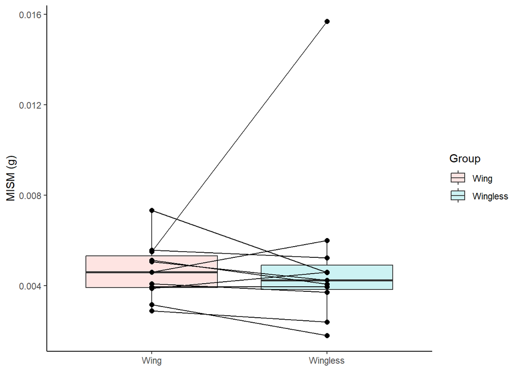

```r
ggplot(data, aes(x = Group, y = MISM)) +
  geom_boxplot(aes(fill = Group), alpha = .2) +
  geom_line(aes(group = ID)) +
  ylab("MISM (g)") +
  theme_classic() +
  theme(axis.title.x = element_blank()) +
  geom_point(size = 2)
```

```r
# compute the difference
d <- with(data,
        MISM[Group == "Wing"] - MISM[Group == "Wingless"])
# Shapiro-Wilk normality test for the differences
shapiro.test(d)
```

```
##
##  Shapiro-Wilk normality test
##
## data:  d
## W = 0.65375, p-value = 0.0001202
```

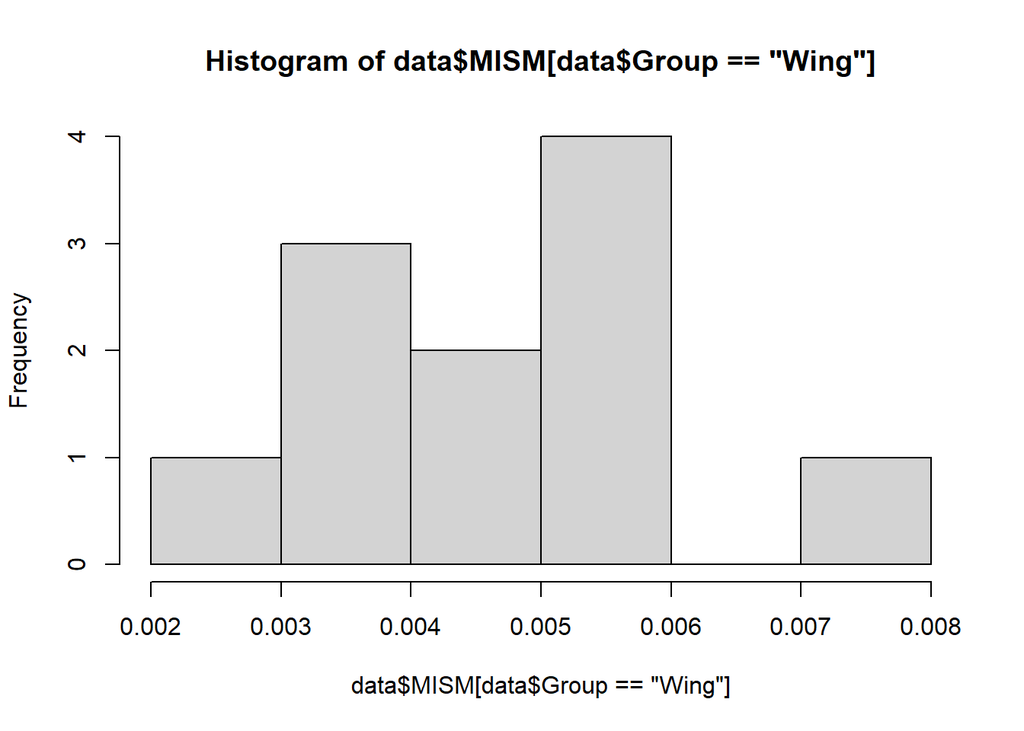

```r
hist(data$MISM[data$Group=="Wing"])
```

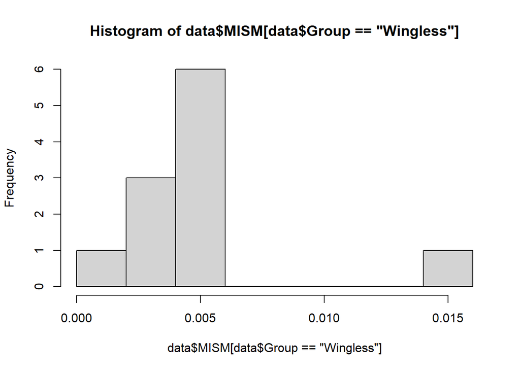

```r
hist(data$MISM[data$Group=="Wingless"])
```

The data are not normally distributed, so let’s do a quick paired wilcoxon signed-rank test.

```r
wilcox.test(data[12:22,3],data[1:11,3], paired = TRUE,alternative="greater")
```

```
##
##  Wilcoxon signed rank exact test
##
## data:  data[12:22, 3] and data[1:11, 3]
## V = 25, p-value = 0.7676
## alternative hypothesis: true location shift is greater than 0
```

Difference in mean weight between seeds from the same cones with + without wings is minimal (non-significant), so we can largely ignore it.

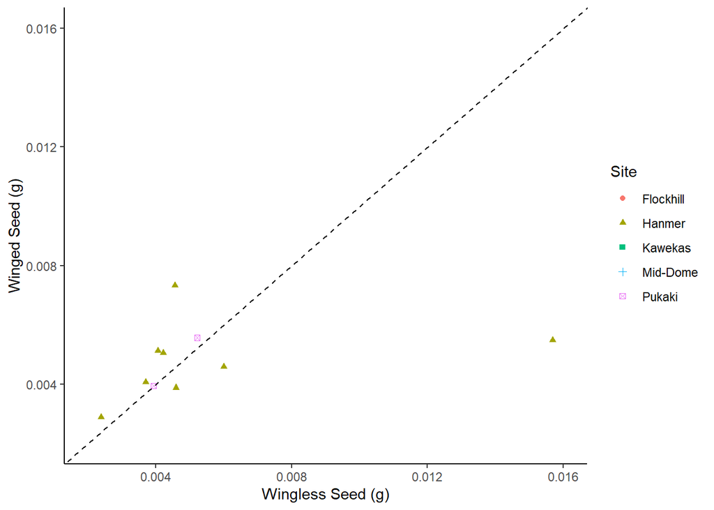

```r
ggplot(con2, aes(x=lessMISM, y=wingMISM, shape=Site, color=Site)) +
  geom_point() +
  theme_classic() +
  xlim(0.002,0.016) +
  ylim(0.002,0.016) +
  geom_abline(slope=1, intercept=0, linetype="dashed") +
  labs(y = "Winged Seed (g)", x = "Wingless Seed (g)")
```

Tweak all figures to be used in manuscript

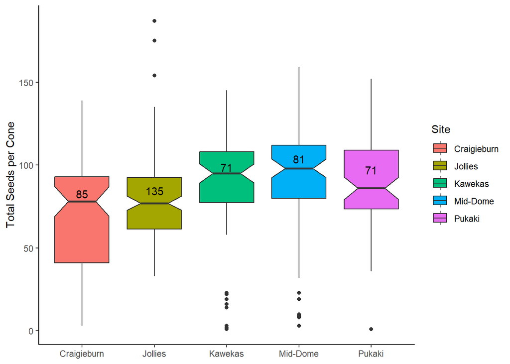

```r
# hue_pal()(5) # Gives 5 default ggplot colours

con3 <- con2
levels(con3$Site)[match("Flockhill",levels(con3$Site))] <- "Craigieburn"
levels(con3$Site)[match("Hanmer",levels(con3$Site))] <- "Jollies"

ggplot(con3, aes(x=Site, y=Tot.Seeds, fill=Site)) +
  geom_boxplot(notch=TRUE) +
  theme_classic() +
  theme(axis.title.x = element_blank()) +
  ylab("Total Seeds per Cone") +
  stat_summary(fun.data = give.n, geom = "text", vjust= c(-2.5,-0.5,-2.1,-1.75,-1))
```

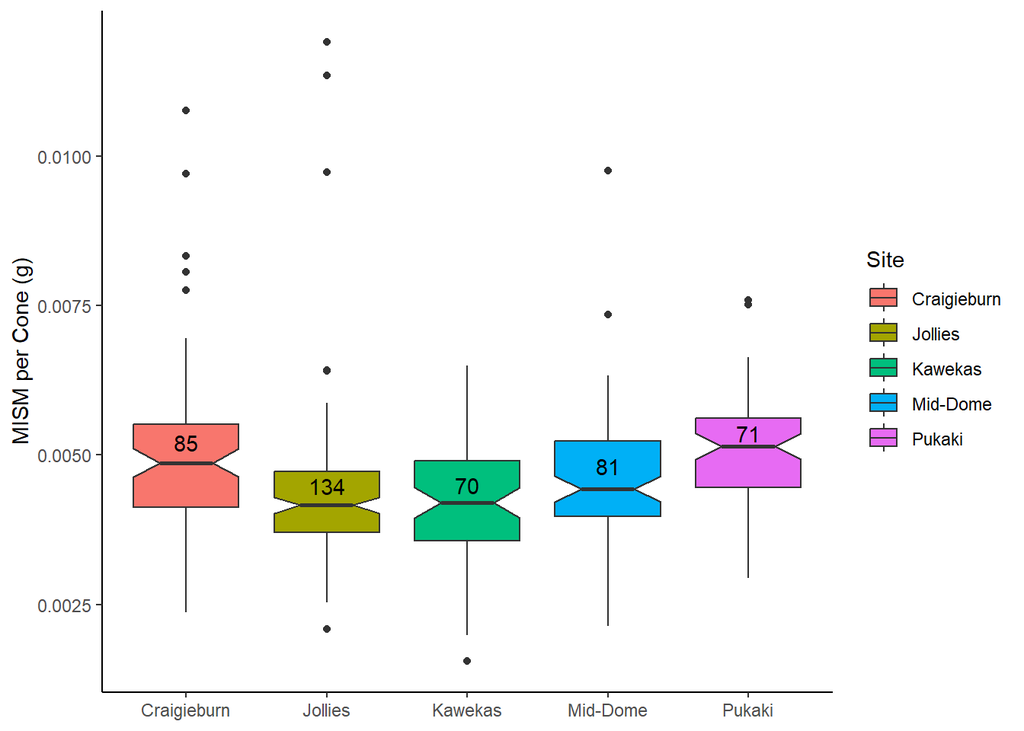

```r
ggplot(con3, aes(x=Site, y=MISM, fill=Site)) +
  geom_boxplot(notch=TRUE) +
  theme_classic() +
  theme(axis.title.x = element_blank()) +
  ylab("MISM per Cone (g)") +
  stat_summary(fun.data = give.n, geom = "text", vjust= c(-0.15,-0.05,-0.6,-0.4,-0.25))
```

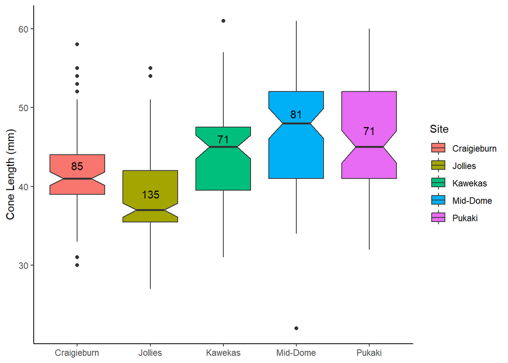

```r
ggplot(con3, aes(x=Site, y=Cone.Length.mm, fill=Site)) +
  geom_boxplot(notch=TRUE) +
  theme_classic() +
  theme(axis.title.x = element_blank()) +
  ylab("Cone Length (mm)") +
  stat_summary(fun.data = give.n, geom = "text", vjust= c(-0.15,-0.05,-1.2,-2,-0.25))
```

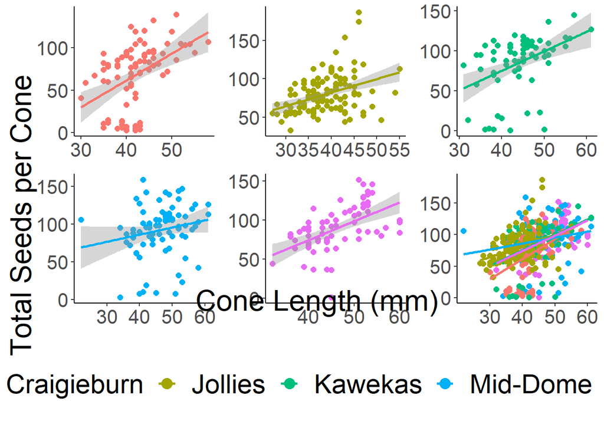

```r
leg <- ggplot(con3, aes(x=Cone.Length.mm, y=Tot.Seeds, color=Site)) +
        geom_point() +
        geom_smooth(method=lm, se=FALSE) +
        theme_classic() +
        theme(legend.position = "bottom",
    legend.title=element_text(size=24),
    legend.text=element_text(size=22)) +
    guides(colour = guide_legend(override.aes = list(size=4)))

a <- ggplot(con3, aes(x=Cone.Length.mm, y=Tot.Seeds, color=Site)) +
  geom_point(size=2) +
  geom_smooth(method=lm, se=FALSE) +
  theme_classic() +
  theme(axis.title.x = element_blank(), axis.title.y = element_blank(),  axis.text.x = element_text(size = 16),
        axis.text.y = element_text(size = 16))

b <- ggplot(con3[con3$Site=="Craigieburn",], aes(x=Cone.Length.mm, y=Tot.Seeds, shape=Site, color="#F8766D")) +
  scale_color_manual(values="#F8766D") +
  geom_point(size=2) +
  geom_smooth(method=lm) +
  theme_classic() +
  theme(axis.title.x = element_blank(), axis.title.y = element_blank(),  axis.text.x = element_text(size = 16),
        axis.text.y = element_text(size = 16))

c <- ggplot(con3[con3$Site=="Jollies",], aes(x=Cone.Length.mm, y=Tot.Seeds, shape=Site, color="#A3A500")) +
  scale_color_manual(values="#A3A500") +
  geom_point(size=2) +
  geom_smooth(method=lm) +
  theme_classic() +
  theme(axis.title.x = element_blank(), axis.title.y = element_blank(),  axis.text.x = element_text(size = 16),
        axis.text.y = element_text(size = 16))

d <- ggplot(con3[con3$Site=="Kawekas",], aes(x=Cone.Length.mm, y=Tot.Seeds, shape=Site, color="#00BF7D")) +
  scale_color_manual(values="#00BF7D") +
  geom_point(size=2) +
  geom_smooth(method=lm) +
  theme_classic() +
  theme(axis.title.x = element_blank(), axis.title.y = element_blank(),  axis.text.x = element_text(size = 16),
        axis.text.y = element_text(size = 16))

e <- ggplot(con3[con3$Site=="Mid-Dome",], aes(x=Cone.Length.mm, y=Tot.Seeds, shape=Site, color="#00B0F6")) +
  scale_color_manual(values="#00B0F6") +
  geom_point(size=2) +
  geom_smooth(method=lm) +
  theme_classic() +
  theme(axis.title.x = element_blank(), axis.title.y = element_blank(),  axis.text.x = element_text(size = 16),
        axis.text.y = element_text(size = 16))

f <- ggplot(con3[con3$Site=="Pukaki",], aes(x=Cone.Length.mm, y=Tot.Seeds, shape=Site, color="#E76BF3")) +
  scale_color_manual(values="#E76BF3") +
  geom_point(size=2) +
  geom_smooth(method=lm) +
  theme_classic() +
  theme(axis.title.x = element_blank(), axis.title.y = element_blank(),  axis.text.x = element_text(size = 16),
        axis.text.y = element_text(size = 16))

fig <- plot_grid(b + theme(legend.position="none"),
           c + theme(legend.position="none"),
           d + theme(legend.position="none"),
           e + theme(legend.position="none"),
           f + theme(legend.position="none"),
           a + theme(legend.position="none"),
           align = 'vh',
           hjust = -1,
           nrow = 2
           )
legend <- get_legend(leg)
p <- plot_grid(fig, "", legend, nrow=3, rel_heights = c(3, .3, .3))
annotate_figure(p, left = textGrob("Total Seeds per Cone", rot = 90, vjust = 0.75, gp = gpar(cex = 2)),
                bottom = textGrob("Cone Length (mm)", vjust = -5, gp = gpar(cex = 2)))
```

```r
# Export figure at 1600 Width 1024 Height
```

Now we need to run the LMM to see if we can use Cone Length to predict Total Number of Seeds

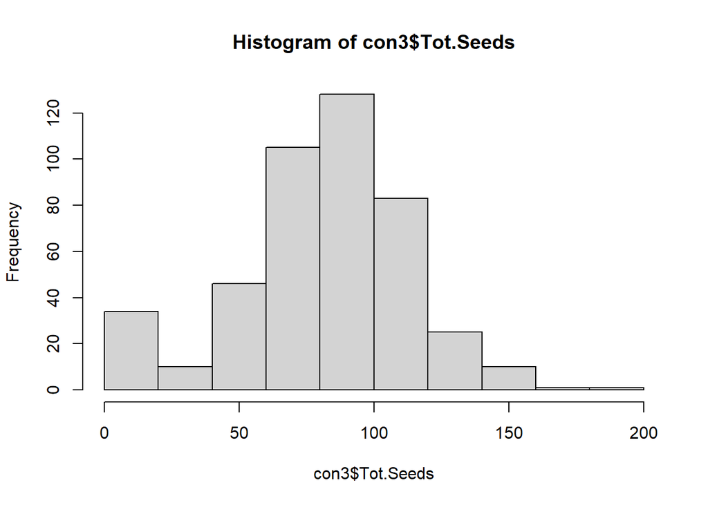

```r
hist(con3$Tot.Seeds)
```

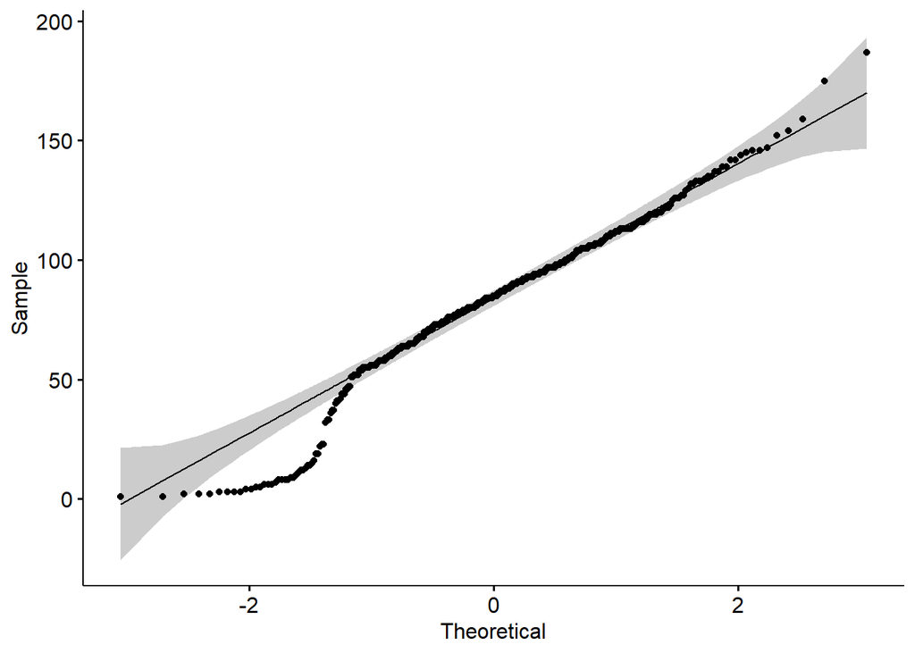

```r
ggqqplot(con3$Tot.Seeds)
```

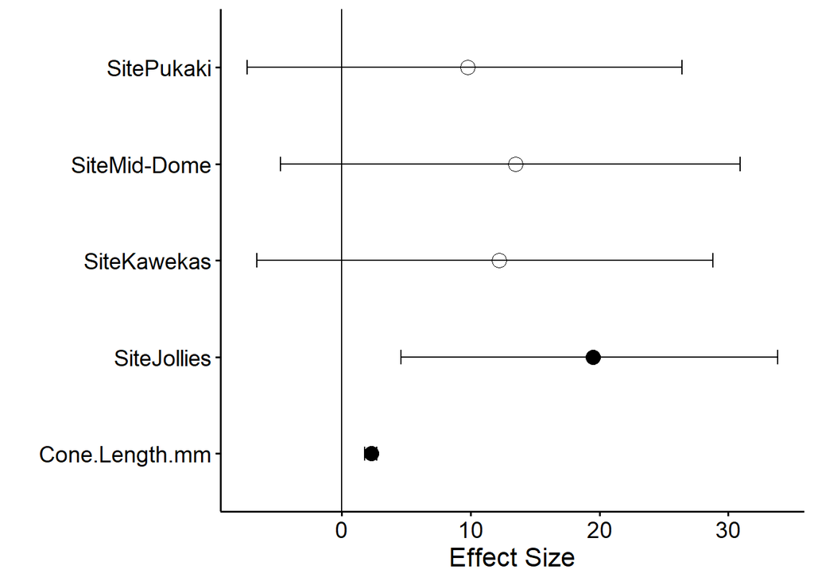

```r
con3$TreeID <- substr(con3$ID,1,nchar(con3$ID)-1)

source("~/VLR/RA1.1/Data/Jennifer_Model_Checks.R") # https://github.com/jbufford/GLMM-Add-Ons/blob/master/Model%20Checks%20JB.R
source("~/VLR/RA1.1/Data/Jennifer_Model_Plots.R") # https://github.com/jbufford/GLMM-Add-Ons/blob/master/Graph%20GLMMs.R

con_lme <- lmer(Tot.Seeds ~ Site + Cone.Length.mm + (1|TreeID), data = con3) # Site * Cone.Length.mm interaction is non-significant
# summary(con_lme)
# Anova(con_lme)
# model.check(con_lme) ### Jennifer's function to run model checks
con_bt <- confint.merMod(con_lme, method="boot",nsim=1000, oldNames = FALSE) ### Do bootstrapping
plot.coef(con_bt, mod = con_lme, main="contorta", intercept = F) ### Jennifer's function to plot data
```

Calculate Summary statistics for a table

```r
seed_avg <- con3 %>% group_by(Site) %>%
    summarise(Seeds=mean(Tot.Seeds),
              .groups = 'drop')
cone_avg <- con3 %>% group_by(Site) %>%
    summarise(Cone_Length=mean(Cone.Length.mm),
              .groups = 'drop')

cone_avg$Intercept <- c(-28.7367,-9.2438,-16.5215,-15.24,-18.9436)
cone_avg$Estimated <- cone_avg$Intercept + cone_avg$Cone_Length * 2.2953
```

Flockhill was always a bit wonky as the trees weren’t completely healthy. Let’s calculate the proportion of developed vs undeveloped seeds to see if it’s different

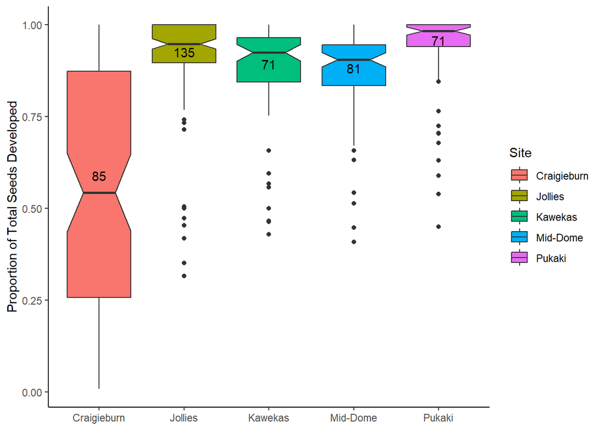

```r
con3$Prop_Dev <- con3$No.Seeds/con3$Tot.Seeds

prop_avg <- con3 %>% group_by(Site) %>%
    summarise(PropDev=mean(Prop_Dev), DevVar=var(Prop_Dev),
              .groups = 'drop')

ggplot(con3, aes(x=Site, y=Prop_Dev, fill=Site)) +
  geom_boxplot(notch=TRUE) +
  theme_classic() +
  theme(axis.title.x = element_blank()) +
  ylab("Proportion of Total Seeds Developed") +
  stat_summary(fun.data = give.n, geom = "text", vjust= c(-0.5,-0.1,-0.1,0.15,-0.5))
```

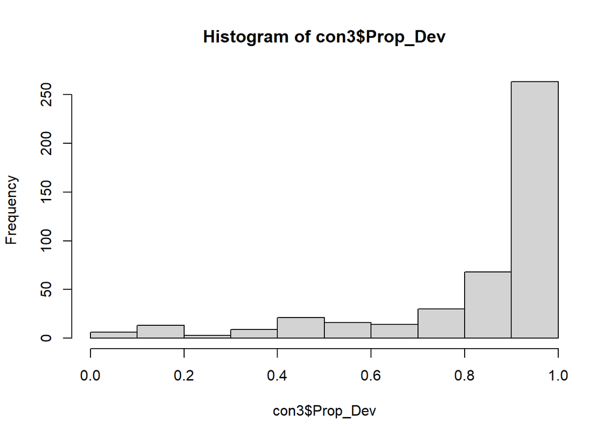

```r
hist(con3$Prop_Dev)
```

```r
kruskal.test(Prop_Dev ~ Site, data = con3)
```

```
##
##  Kruskal-Wallis rank sum test
##
## data:  Prop_Dev by Site
## Kruskal-Wallis chi-squared = 82.026, df = 4, p-value < 2.2e-16
```

```r
pairwise.wilcox.test(con3$Prop_Dev, con3$Site, p.adjust.method = "BH")
```

```
##
##  Pairwise comparisons using Wilcoxon rank sum test with continuity correction
##
## data:  con3$Prop_Dev and con3$Site
##
##          Craigieburn Jollies Kawekas Mid-Dome
## Jollies  2.9e-11     -       -       -
## Kawekas  7.3e-07     0.0185  -       -
## Mid-Dome 1.9e-07     0.0007  0.3157  -
## Pukaki   6.1e-10     0.0206  1.2e-05 4.3e-06
##
## P value adjustment method: BH
```

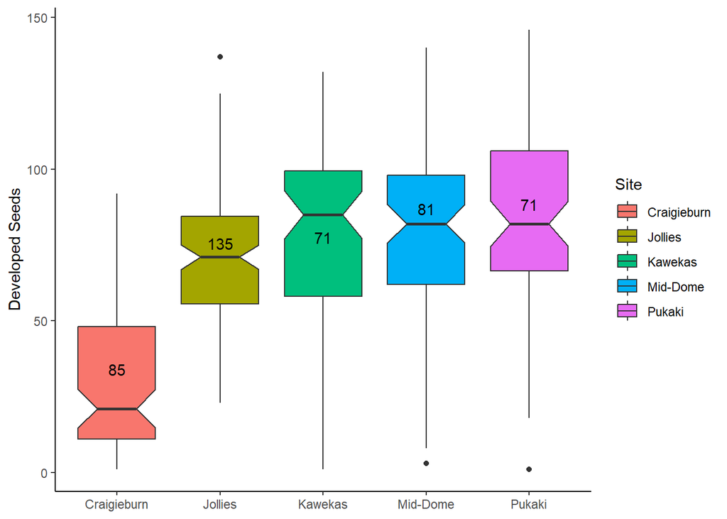

```r
dev_seed <- con3 %>% group_by(Site) %>%
    summarise(SeedDev=mean(No.Seeds), SeedVar=var(No.Seeds),
              .groups = 'drop')

ggplot(con3, aes(x=Site, y=No.Seeds, fill=Site)) +
  geom_boxplot(notch=TRUE) +
  theme_classic() +
  theme(axis.title.x = element_blank()) +
  ylab("Developed Seeds") +
  stat_summary(fun.data = give.n, geom = "text", vjust= c(-0.5,-0.5,-0.2,-1.5,-0.5))
```